# Workshop4_NOsolutions

Giulia Marchello

11/17/2020

# Exercise 1

### Download the dataset : [winequality-red.csv](https://archive.ics.uci.edu/ml/datasets/wine+quality) and show the summary.

### Add the variable “label” for alcohol percentage (alcohol variable) to group the alcohol concentration in the following way:

Light $<$ 9; 9 $\leq$ Medium $<$ 12 ; Strong $\geq$ 12

### How many Light, Medium and Strong wines there are in the dataset?

### Create a barplot for the 3 levels variable “label” where the color of bars depends on the level of the alcohol concentration, with title: “Alcohol concentration”

### Show histograms for fixed.acidity by label

### Create a density plot taking into account the citric.acid for the three level of the variable “label”

### Create a boxplot for the overall dataset

Consider the log scale

### Create a scatter plot quality and alcohol where the color of points varies depending on the following quality ranges $(2,4], (4,6], (6,8]$. Add a dashed line for the median. Give a title to the plot and to the x and y axes

Use `geom_jitter()` instead of `geom_point()`

# Exercise 2 - Dplyr recap

`libarry(tidyverse)` `library(dplyr)` `library(gapminder)`

### Load the dataset gapminder from the package gapminder

### Create a tibble $5 \times 4$ containing the number of observation per continent, the number of countries per continent and the average of life expectation.

### Show the columns of country, year, lifeExp and add a variable that represents the year of life expectacy gained with respect to 1957, for each country, until 1963.

### What was the most populous European country in 1992? Modify the population variable by dividing it by $10^6$. Show the results sorted according to population in a descendent order.

### Draw a scatterplot of gdpPercap and lifeExp where the color of points depends on the continent. Overall also a smooth line (*loess*) with it’s confidence intervals. Give the plot a title and axis labels.

Hint: log scale x axis

# Exercise 3

## Instructions:

Select a dataset and variables to be used for clustering:  
- Iris dataset, variable Species not included.  
- mtcars dataset, considering only the following variables : ‘mpg’,‘disp’, ‘wt’.  
Indicate the desired number of clusters to be used and display the results in a scatterplot where colors depend on clusters.  
Hint : add `runtime: shiny` to the YAML-Header.

### Example :

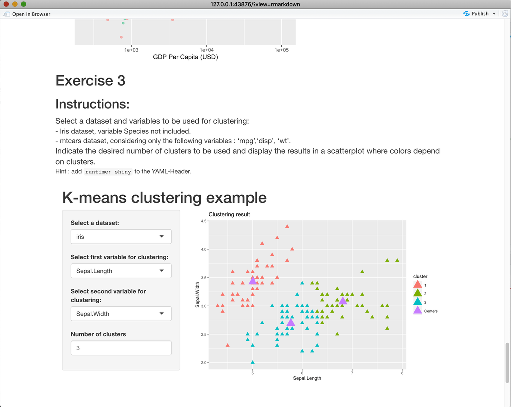

Example Image